# STAT6011 Assignment 1

Yu Boyang / ID: 3030144197

# Question 1

## (a)

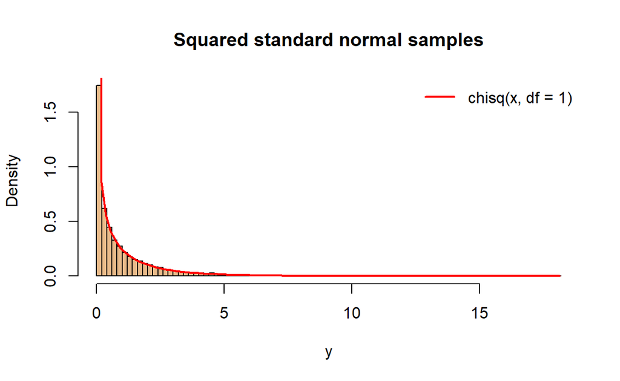

```r
set.seed(6001)
x <- rnorm(10000)
y <- x^2
hist(y, breaks = 100, probability = TRUE, col = "#e9bb8a",
     main = "Squared standard normal samples", xlab = "y")
curve(dchisq(x, df = 1), from = 0.0001, to = max(y),
      add = TRUE, col = "red", lwd = 2)
legend("topright", "chisq(x, df = 1)", col = "red", lwd = 2, bty = "n")
```

The histogram is very similar and very close to the chi-squared(df=1) density.

## (b)

Use a one-sample Kolmogorov–Smirnov test with $H_0:Y\sim\chi^2_1$.

```r
ks <- ks.test(y, "pchisq", df = 1)
ks
```

```
##
##  Asymptotic one-sample Kolmogorov-Smirnov test
##
## data:  y
## D = 0.00647, p-value = 0.8
## alternative hypothesis: two-sided
```

At the 5% level, do not reject $H_0$ (p-value = 0.7972).

# Question 2

## (a)

```r
h <- function(x) (cos(50*x) + sin(20*x))^2
set.seed(6001)
n <- 10000
u <- runif(n)
mc <- mean(h(u))
mc.se <- sd(h(u))/sqrt(n)
c(estimate = mc, MCSE = mc.se)
```

```
## estimate     MCSE
## 0.958516 0.010379
```

## (b)

For $U_i\sim\mathrm{Beta}(\alpha,\beta)$,
$$\widehat I=\frac1n\sum_i\frac{h(U_i)}{f(U_i)},\qquad
\operatorname{Var}(\widehat I)=\frac1n\left[
\int_0^1\frac{h(x)^2}{f(x)}dx-I^2\right].$$
Minimize $\int_0^1h(x)^2/f(x)dx$ over $0<\alpha,\beta<2$.

```r
second.moment <- function(ab) {
  integrate(function(x) h(x)^2/dbeta(x, ab[1], ab[2]),
            0, 1, subdivisions = 1000)$value
}
opt <- optim(c(1, 1), second.moment, method = "L-BFGS-B",
             lower = c(.01, .01), upper = c(1.99, 1.99))
ab <- opt$par
names(ab) <- c("alpha", "beta")
ab
```

```
##  alpha   beta
## 1.0780 1.0145
```

```r
set.seed(6001)
u.beta <- rbeta(n, ab[1], ab[2])
z <- h(u.beta)/dbeta(u.beta, ab[1], ab[2])
is <- mean(z)
is.se <- sd(z)/sqrt(n)
c(estimate = is, MCSE = is.se)
```

```
## estimate     MCSE
## 0.964754 0.010377
```

The optimal values are $\alpha\approx 1.078$ and $\beta\approx 1.0145$.

## (c)

Use Gauss–Legendre quadrature with $x=(t+1)/2$:
$$I\approx\frac12\sum_k w_kh((t_k+1)/2).$$

```r
gauss.int <- function(m) {
  g <- statmod::gauss.quad(m, kind = "legendre")
  sum(g$weights*h((g$nodes + 1)/2))/2
}
benchmark <- gauss.int(128)
benchmark
```

```
## [1] 0.9652
```

```r
comparison <- data.frame(
  method = c("Uniform MC", "Beta importance sampling", "Gauss-Legendre"),
  estimate = c(mc, is, benchmark),
  MCSE = c(mc.se, is.se, NA))
comparison$absolute.error <- abs(comparison$estimate - benchmark)
knitr::kable(longtable = FALSE, comparison, digits = 7)
```

| method | estimate | MCSE | absolute.error |
| --- | --- | --- | --- |
| Uniform MC | 0.95852 | 0.010379 | 0.0066852 |
| Beta importance sampling | 0.96475 | 0.010377 | 0.0004466 |
| Gauss-Legendre | 0.96520 | NA | 0.0000000 |

```r
var.uniform <- second.moment(c(1, 1)) - benchmark^2
var.beta <- second.moment(ab) - benchmark^2
c(variance.ratio = var.beta/var.uniform,
  variance.reduction = 1 - var.beta/var.uniform)
```

```
##     variance.ratio variance.reduction
##          0.9930797          0.0069203
```

The integral is about 0.9652. The Beta proposal reduces variance by about 0.69%.

# Question 3

## (a)

```r
d <- read.csv("Q3.csv", row.names = 1)
fit <- lm(y ~ ., data = d)
X <- model.matrix(fit)
y3 <- d$y
n3 <- nrow(X)
p <- ncol(X)
bhat <- coef(fit)
S <- sum(resid(fit)^2)
vhat <- S/n3
log.Lmax <- -n3/2*(log(2*pi*vhat) + 1)
c(sigma2.MLE = vhat, log.Lmax = log.Lmax)
```

```
## sigma2.MLE   log.Lmax
##     0.8004  -130.7617
```

Use $\widehat\beta=(X^TX)^{-1}X^Ty$ and $\widehat\sigma^2=S/n$. Accept a prior sample with probability $L(\beta,\sigma^2)/L(\widehat\beta,\widehat\sigma^2)$.

```r
prior.reject <- function(prior) {
  accepted <- 0
  for (i in 1:100) {
    if (prior == "normal") {
      b <- matrix(rnorm(10000*p, sd = 5), nrow = 10000)
    } else {
      b <- matrix(rexp(10000*p)*sample(c(-1, 1), 10000*p, TRUE),
                  nrow = 10000)
    }
    v <- 1/rgamma(10000, .1, rate = .1)
    rss <- colSums((y3 - X %*% t(b))^2)
    log.a <- n3/2*(log(vhat/v) + 1) - rss/(2*v)
    accepted <- accepted + sum(log(runif(10000)) <= log.a)
  }
  accepted
}
```

```r
set.seed(6001)
prior.reject("normal")
```

```
## [1] 0
```

So tried 1,000,000 proposals but got no accepted samples, just like the student on moodle stated.

## (b)

```r
prior.reject("laplace")
```

```
## [1] 0
```

The Laplace prior also gave no accepted samples after 1,000,000 proposals, so could not compare their efficiency from these runs.

## (c)

Fit ridge and Lasso using 10-fold cross-validation.

```r
set.seed(6001)
fold <- sample(rep(1:10, length.out = n3))
x3 <- as.matrix(d[, paste0("x", 1:10)])
cv.ridge <- glmnet::cv.glmnet(x3, y3, alpha = 0, foldid = fold)
cv.lasso <- glmnet::cv.glmnet(x3, y3, alpha = 1, foldid = fold)
knitr::kable(longtable = FALSE, data.frame(parameter = c("beta0", paste0("beta", 1:10)),
  MLE = bhat,
  Ridge.CV = as.numeric(coef(cv.ridge, s = "lambda.min")),
  Lasso.CV = as.numeric(coef(cv.lasso, s = "lambda.min"))),
  digits = 4, row.names = FALSE)
```

| parameter | MLE | Ridge.CV | Lasso.CV |
| --- | --- | --- | --- |
| beta0 | 1.1671 | 1.1774 | 0.9455 |
| beta1 | 0.9791 | 0.9132 | 0.9321 |
| beta2 | 0.6033 | 0.5606 | 0.5686 |
| beta3 | -0.0505 | -0.0713 | 0.0000 |
| beta4 | 0.0517 | 0.0301 | 0.0000 |
| beta5 | 0.3775 | 0.3877 | 0.2776 |
| beta6 | 0.1162 | 0.0967 | 0.0576 |
| beta7 | 0.0336 | 0.0451 | 0.0000 |
| beta8 | -0.4191 | -0.4507 | 0.0000 |
| beta9 | -0.4019 | -0.4120 | -0.3381 |
| beta10 | 0.2154 | 0.1932 | 0.1274 |

```r
c(ridge.lambda = cv.ridge$lambda.min, lasso.lambda = cv.lasso$lambda.min)
```

```
## ridge.lambda lasso.lambda
##     0.104269     0.053116
```

Ridge shrinks the coefficients, while Lasso sets some coefficients to zero.

# Question 4

## (a)

For $\mu\sim N(m,4)$,
$$p(\mu\mid y)\propto\exp\left[-\frac12\left\{
\sum_i(y_i-\mu)^2+\frac{(\mu-m)^2}{4}\right\}\right].$$
Completing the square,
$$\mu\mid y\sim N\left(\frac{n\bar y+m/4}{n+1/4},\frac1{n+1/4}\right).$$
Set $m=0$ for the given prior.

```r
y4 <- read.csv("Q4.csv", row.names = 1)$y
n4 <- length(y4)
ybar <- mean(y4)
post.var <- 1/(n4 + 1/4)
c(MLE = ybar, posterior.mean = n4*ybar*post.var,
  posterior.variance = post.var)
```

```
##                MLE     posterior.mean posterior.variance
##          0.8420000          0.8399002          0.0099751
```

## (b)

The mean update is
$$m_{j+1}=\frac{n\bar y+m_j/4}{n+1/4},\qquad
m_{j+1}-\bar y=\frac{m_j-\bar y}{4n+1}.$$
Thus the fixed point is $\bar y$. Use 1000 samples per iteration and stop when the mean changes by less than 0.01.

```r
set.seed(6001)
m <- 0
trace <- m
for (j in 1:100) {
  post.mean <- (n4*ybar + m/4)*post.var
  draws <- rnorm(1000, post.mean, sqrt(post.var))
  m.new <- mean(draws)
  change <- abs(m.new - m)
  m <- m.new
  trace <- c(trace, m)
  if (change < .01) break
}
c(PPMM = m, MLE = ybar)
```

```
##    PPMM     MLE
## 0.84408 0.84200
```

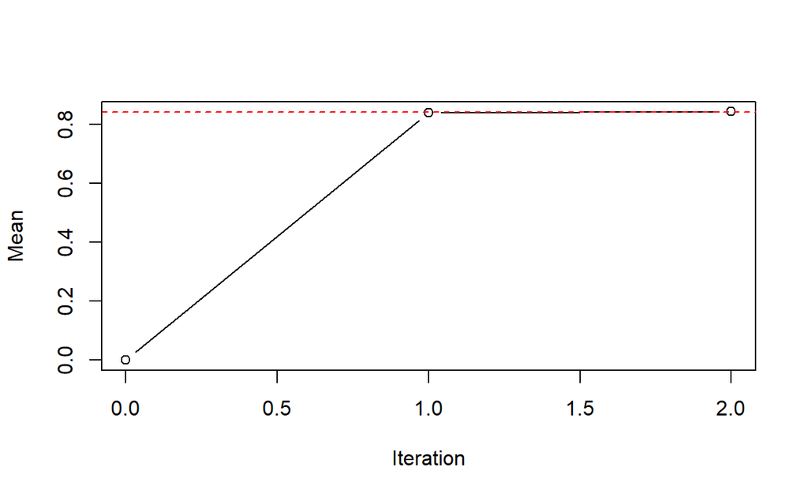

```r
plot(0:j, trace, type = "b", xlab = "Iteration", ylab = "Mean")
abline(h = ybar, col = "red", lty = 2)
```

The PPMM estimate is 0.84408, and the MLE is 0.842, saying they are close.